# Bioinformatics Analysis and Visualisation of Medical Genomics Data - Week 2

Rodrigo Arcoverde Cerveira

2023-10-17

# 1 Load libraries

This R code chunk is loading the needed libraries.

```r
# Load libraries
# if you do not have libraries, they are located in either CRAN or Bioconductor
# libraries should be able to be automatically retrieved using renv::restore() function.
library(ComplexHeatmap)
library(grid)
library(tidyverse)
library(ggsci)
library(ggprism)
```

# 2 Load data

```r
# Load tab separated file to generate the plot
sle_state_degs <- read.table(paste0(data.dir, "/Disease_state_DEG_sumstats.txt"), sep = "\t", header = TRUE)
sle_activity_degs <- read.table(paste0(data.dir, "/Disease_activity_DEG_sumstats.txt"), sep = "\t", header = TRUE)

# Merge datasets based on cell type and gene
merged_degs <- full_join(sle_activity_degs, sle_state_degs,by = c("Cell.type","Gene"), suffix = c("_activity", "_state"))

# Use pivot_longer to reshape the data
long_merged_degs <- merged_degs %>%
  pivot_longer(
    cols = c("FDR_state", "FDR_activity"),
    names_to = "type",
    values_to =  "FDR"
  ) %>%
  mutate(type = gsub("FDR_", "", type))
```

# 3 Set lineages names

The code assigns lineage names to specific cell types based on predefined subsets. It creates a new column, cell_lineage, in the dataset long_merged_degs, and classifies each cell type into one of several predefined lineages. If a cell type doesn’t match any subset, it’s categorized as “Other.”

```r
# Define subsets of cell types within different lineages
subsets <- list(
    CD4 = c("Naive CD4", "Mem CD4", "Th1", "Th2", "Th17", "Tfh", "Fr. I nTreg", "Fr. II eTreg", "Fr. III T"),
    CD8 = c("Naive CD8", "CM CD8", "EM CD8", "TEMRA CD8"),
    B = c("Naive B", "USM B", "SM B", "DN B", "Plasmablast"),
    Monocyte = c("CL Mono", "CD16p Mono", "Int Mono", "NC Mono"),
    DC = c("pDC", "mDC"),
    Neutrophils = c("Neu", "LDG"))

# Add a 'cell_lineage' column to the 'long_merged_degs' dataset
long_merged_degs <- long_merged_degs %>%
  mutate(cell_lineage = case_when(
    # Assign cell lineages based on cell types
    Cell.type %in% subsets$CD4 ~ "CD4+ T cells",
    Cell.type %in% subsets$CD8 ~ "CD8+ T cells",
    Cell.type %in% subsets$B ~ "B cells",
    Cell.type %in% subsets$Monocyte ~ "Monocytes",
    Cell.type %in% subsets$DC ~ "Dendritic cell",
    Cell.type %in% subsets$Neutrophils ~ "Neutrophils",
    Cell.type == "NK" ~ "Natural killer cells",
    TRUE ~ "Other"  # If not found in any subset, assign as 'Other'
  ))
```

# 4 Jaccard indices calculation

The code computes Jaccard indices for cell types based on gene expression data. It processes and categorizes genes into “Disease-activity only,” “Disease-state only,” and “Both significant” groups. Proportions of these categories are calculated within each cell type. Dominance is determined, classifying cell types as “Disease state dominant,” “Disease activity dominant,” or “Shared dominant.” An ‘order_plot’ value for visualization is also created, providing insights into gene regulation within cell types and their roles in disease states or activities.

```r
# Transform gene expression data into a wide format and calculate gene significance
filtered_degs_fc <- long_merged_degs %>%
  pivot_wider(names_from = type, values_from = FDR) %>%
  mutate(
    # Categorize genes into 'degs_presence' based on significance and regulation
    degs_presence = case_when(
      state < 0.05 & activity < 0.05 & (logFC_state * logFC_activity) > 0 ~ "Both significant",
      activity < 0.05 ~ "Disease-activity only",
      state < 0.05 ~ "Disease-state only",
      TRUE ~ "non_significant"
    ),
    regulation = case_when(
      logFC_state > 0 & logFC_activity > 0 ~ "Upregulated",
      logFC_state < 0 & logFC_activity < 0 ~ "Downregulated",
      logFC_state > 0 & logFC_activity < 0 ~ "Upregulated disease-state",
      logFC_state < 0 & logFC_activity > 0 ~ "Upregulated disease-activity"
    )
  ) %>%
  filter(degs_presence != "non_significant")  # Filter out non-significant genes

# Group and summarize gene information within cell types and lineages
filtered_degs <- filtered_degs_fc %>%
  group_by(Cell.type, cell_lineage) %>%
  summarize(
    total_degs = n(),
    "Disease-activity only" = sum(degs_presence == "Disease-activity only") / n(),
    "Disease-state only" = sum(degs_presence == "Disease-state only") / n(),
    "Both significant" = sum(degs_presence == "Both significant") / n()
  ) %>%
  pivot_longer(
    cols = c("Disease-activity only", "Disease-state only", "Both significant"),
    values_to = "proportion",
    names_to = "degs_presence"
  ) %>%
  ungroup()

# Determine gene category dominance and create an 'order_plot' value for visualization
filtered_degs <- filtered_degs %>%
  group_by(Cell.type) %>%
  mutate(
    dominance = case_when(
      proportion[degs_presence == "Both significant"] > 0.15 ~ "Shared dominant",
      proportion[degs_presence == "Disease-activity only"] > proportion[degs_presence == "Disease-state only"] ~ paste("Disease activity dominant"),
      TRUE ~ "Disease state dominant"
    ),
    order_plot = case_when(
      dominance == "Disease state dominant" ~ 10 + proportion,
      dominance == "Disease activity dominant" ~ 100 + proportion,
      dominance == "Shared dominant" ~ 1000 + proportion[degs_presence == "Both significant"]
    )
  )
```

# 5 Plot bar plot for total Differentially Expressed Genes

The provided code calculates summary statistics for the number of differentially expressed genes (DEGs) within specific categories of cell types, cell lineages, and dominance. It then creates a bar plot using ggplot2 to visualize these statistics. The x-axis is reordered based on ‘order_plot’ values, improving the representation of the data. The bar plot displays the number of DEGs, with each bar color-coded by cell lineage.

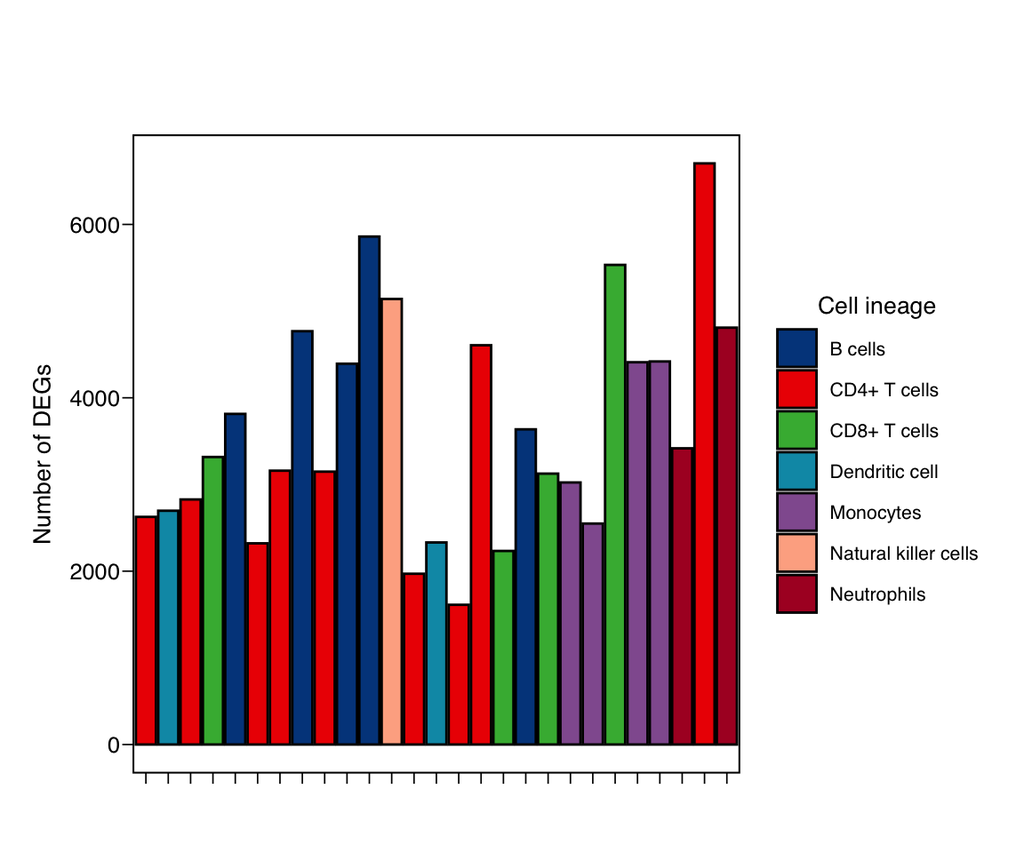

```r
# Calculate summary statistics for DEGs
summ_degs_stats <- filtered_degs %>%
  group_by(Cell.type, cell_lineage, dominance) %>%
  summarise(summ_degs = max(total_degs),
            order_plot = max(order_plot)) %>%
  distinct()

# Create a bar plot using ggplot2
g1 <- summ_degs_stats %>%
  ggplot(aes(y = summ_degs, x = fct_reorder(Cell.type, order_plot), fill = cell_lineage)) +
  geom_col(color = "black") +
  scale_fill_lancet() +
  labs(y = "Number of DEGs", x = "", fill = "Cell ineage") +
  theme_prism(base_fontface = "plain", base_line_size = .3, base_size = 10, border = TRUE) +
  theme(axis.text.x = element_blank(),
        legend.title = element_text(),
        legend.position = "right",
        plot.margin = margin(2,.5,.5,.5, "cm"))

g1
```

# 6 Plot proportion of degs

The code presented generates a visualization to depict the proportion of differentially expressed genes (DEGs) across various categories. It first calculates summary statistics for DEGs, considering cell type, cell lineage, and dominance. The resulting values help in organizing the plot. Using ggplot2, the script creates a bar plot with x-axis labels reordered based on the ‘order_plot’ values, improving the presentation of data. The fill colors represent different DEG types. This visualization provides insights into how DEGs are distributed among different cell types and their respective lineages, offering a clear representation of their proportions.

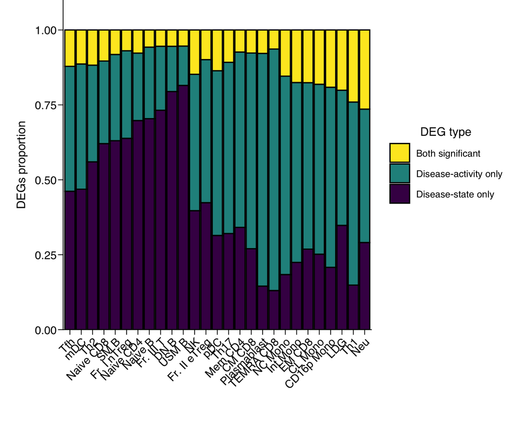

```r
# Create column with correct order based on the maximum value of the proprotion of degs
g2 <- filtered_degs %>%
  group_by(Cell.type, cell_lineage, dominance) %>%
  mutate(summ_degs = max(total_degs),
            order_plot = max(order_plot)) %>%
# Plot a stacked bar plot of the proportions of each cell type
  ggplot(aes(x = fct_reorder(Cell.type, order_plot), y = proportion, fill = degs_presence)) +
  geom_col(color = "black") +
  scale_fill_viridis_d(direction = -1, option = "D") +
  scale_y_continuous(expand = c(0,0), limits = c(0,1.1)) +
  labs(x = "", y = "DEGs proportion", fill = "DEG type") +
  theme_prism(base_fontface = "plain", base_line_size = .3, base_size = 10, border = FALSE) +
  theme(axis.text.x = element_text(angle = 45, vjust = 1, hjust = 1),
        legend.title = element_text(),
        legend.position = "right",
        plot.margin = margin(0,.1,.5,.5, "cm"))

g2
```

# 7 Merge plots and save them

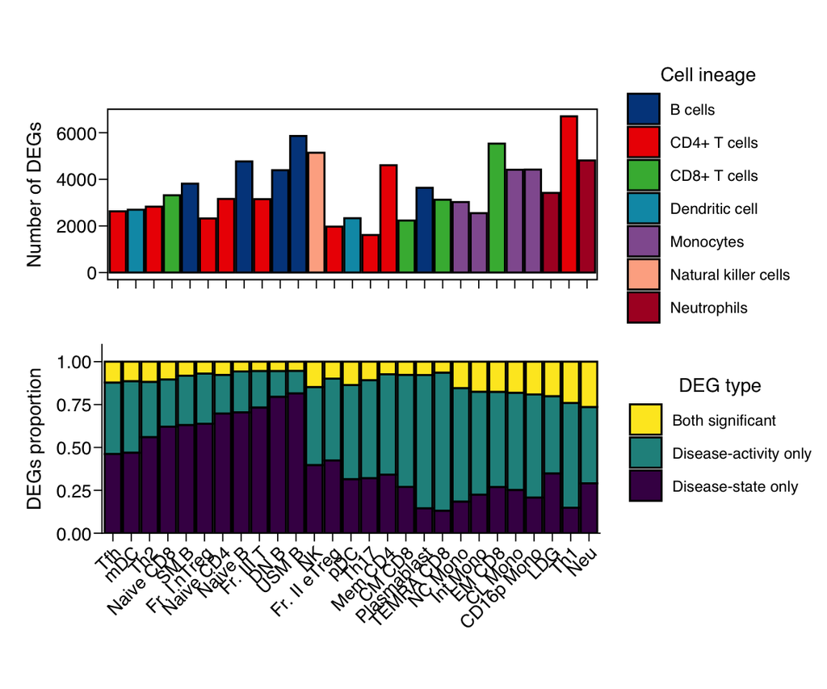

```r
merged_plot_degs <- gridExtra::grid.arrange(g1,g2, ncol = 1, as.table = FALSE)
```

```r
ggsave(merged_plot_degs, filename = paste0(result.dir, "/merged_plot.pdf"), height = 5, width = 7)
```

# 8 Data transformation for heatmap

Exploring another visualization tool for the proportion of DEGs from the same paper.This way, the proportion of both upregulated and downregulated are for the classication, which in the original paper the type of DEGs (up or down) is not taken into consideration in the main figure.

```r
# Group data by 'Cell.type,' 'cell_lineage,' and 'regulation'
filtered_degs_fc_plot <- filtered_degs_fc %>%
  group_by(Cell.type, cell_lineage, regulation) %>%

  # Calculate total number of DEGs and proportions of different DEG types
  summarize(
    total_degs = n(),
    "Disease-activity only" = sum(degs_presence == "Disease-activity only") / n(),
    "Disease-state only" = sum(degs_presence == "Disease-state only") / n(),
    "Both significant" = sum(degs_presence == "Both significant") / n(),
  ) %>%

  # Convert data to a longer format for further analysis
  pivot_longer(
    cols = c("Disease-activity only", "Disease-state only", "Both significant"),
    values_to = "proportion",
    names_to = "degs_presence"
  ) %>%

  # Ungroup the data
  ungroup()

# Further data manipulation to determine 'dominance' and 'order_plot'
filtered_degs_fc_plot <- filtered_degs_fc_plot %>%
  group_by(Cell.type, regulation) %>%

  # Define 'dominance' based on specific conditions
  mutate(
    dominance = case_when(
      proportion[degs_presence == "Both significant"] > 0.15 ~ "Shared dominant",
      proportion[degs_presence == "Disease-activity only"] > proportion[degs_presence == "Disease-state only"] ~ paste("Disease activity dominant"),
      TRUE ~ "Disease state dominant"
    ),

    # Assign 'order_plot' values based on 'dominance'
    order_plot = case_when(
      dominance == "Disease state dominant" ~ 10 + proportion,
      dominance == "Disease activity dominant" ~ 100 + proportion,
      dominance == "Shared dominant" ~ 1000 + proportion[degs_presence == "Both significant"]
    )
  )

# Final data structure for heatmap visualization
filtered_degs_matrix <- filtered_degs_fc_plot %>%
  group_by(Cell.type, cell_lineage, dominance) %>%

  # Determine the maximum values for 'total_degs' and 'order_plot'
  mutate(
    summ_degs = max(total_degs),
    order_plot = max(order_plot)
  ) %>%

  # Filter data based on 'regulation' for 'Upregulated' and 'Downregulated' DEGs
  filter(regulation %in% c("Upregulated", "Downregulated")) %>%

  # Ungroup the data
  ungroup() %>%

  # Select and pivot data to create the heatmap matrix
  select(Cell.type, proportion, regulation, degs_presence) %>%
  pivot_wider(values_from = "proportion", names_from = c("degs_presence", "regulation")) %>%
  column_to_rownames("Cell.type") %>%

  # Convert data to a matrix and transpose
  as.matrix() %>% t()
```

Besides plotting the heatmap itself, hierarchical clustering is applied to categorize cell line groups based on the proportion of DEGs. The results generated above are suitable for heatmaps, enabling the visualization of DEG proportions within different cell types and their regulatory patterns.

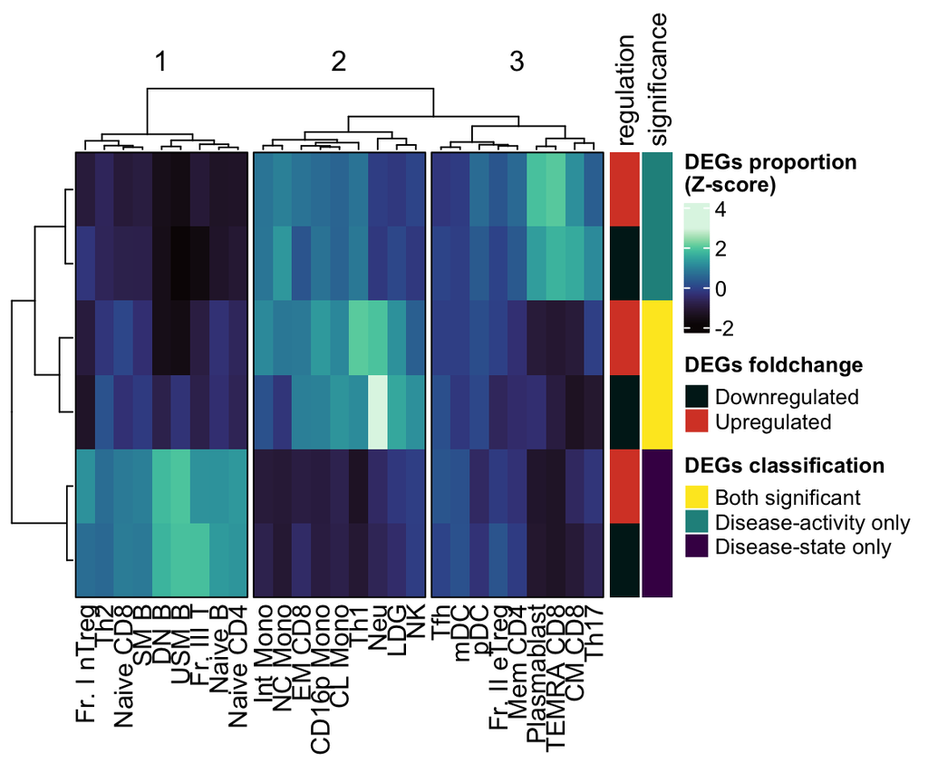

```r
# Set the color palette using 'viridis' with 100 color options
my_palette <- viridisLite::viridis(100, option = "mako")

# Create annotations for row names by extracting text after the last "_" in row names
row_annotation <- gsub("^.+_", "", rownames(filtered_degs_matrix))
row_annotation_2 <- gsub("_.*$", "", rownames(filtered_degs_matrix))

# Define color values for different row annotations
row_col_reg <- c(Upregulated = "#D84630", Downregulated = "#001E1D")
row_col_sig <- c("Both significant" = "#FDE725FF",
                 "Disease-state only" = "#440154FF",
                 "Disease-activity only" = "#21908CFF")

# Create row annotations for heatmap
row_anno <- rowAnnotation(
  regulation = gsub("^.+_", "", rownames(filtered_degs_matrix)),
  significance = gsub("_.*$", "", rownames(filtered_degs_matrix)),
  annotation_name_side = "top",
  col = list(regulation = row_col_reg, significance = row_col_sig),
  annotation_legend_param = list(
    regulation = list(title = "DEGs foldchange"),
    significance = list(title = "DEGs classification")
  )
)

# Scale rows of matrix

filtered_degs_matrix_scaled <- filtered_degs_matrix %>% t() %>% scale() %>% t()

# Generate a heatmap using specified parameters and annotations
heatmap1 <- Heatmap(filtered_degs_matrix_scaled, border = T,
        cluster_rows = TRUE, cluster_columns = TRUE,
        clustering_method_rows = "ward.D2", clustering_method_columns = "ward.D2",
        col = my_palette, show_row_names = FALSE, column_split = 3,
        name = "DEGs proportion\n(Z-score)", right_annotation = row_anno)
heatmap1
```

```r
{
  pdf(file = paste0(result.dir, "/heatmap_plot.pdf"), height = 5, width = 7)
  draw(heatmap1)
  dev.off()
}
```

In conclusion, we can conclude two main points from this visulization and comparison with the previous plot. * The up and downregulated genes have the same proportions across the different DEGs classification. Thus, the analysis with them combined does not impact the grouping strategy based on the proportion of DEGs.The clustering by row is maintained based on DEGs classification rather than if the genes are up or down regulated. * Hierarchical clustering could have been a alternative to separate the the lineages in a more data-driven manner than using manual thresholds. Some of the subpopulations ended up in a different group than when compared with the original grouping in the article.